# 21-01 주제분석 2주차 패키지

```python
import pandas as pd
import numpy as np
```

## 1. 데이터 분할

### 1.1 데이터 불러오기

```python
train=pd.read_csv('C:/Users/paa04/OneDrive/바탕 화면/P-SAT/21-1/데마/주제분석/2주차패키지/train.csv')
test=pd.read_csv('C:/Users/paa04/OneDrive/바탕 화면/P-SAT/21-1/데마/주제분석/2주차패키지/test.csv')
```

```python
train
```

|  | dong | apt | exclusive_use_area | floor | price | transaction_year | until_trans | sin_date | cos_date |
| --- | --- | --- | --- | --- | --- | --- | --- | --- | --- |
| 0 | 사직동 | 광화문풍림스페이스본(9-0) | 95.88 | 6 | 70000 | 0 | 5 | -1.000000e+00 | -1.836970e-16 |
| 1 | 사직동 | 광화문풍림스페이스본(9-0) | 108.55 | 11 | 100500 | 0 | 5 | -2.449294e-16 | 1.000000e+00 |
| 2 | 사직동 | 광화문풍림스페이스본(9-0) | 94.51 | 1 | 65800 | 0 | 5 | -2.449294e-16 | 1.000000e+00 |
| 3 | 수송동 | 로얄팰리스스위트 | 42.87 | 8 | 30500 | 0 | 8 | -1.000000e+00 | -1.836970e-16 |
| 4 | 수송동 | 로얄팰리스스위트 | 39.67 | 15 | 30500 | 0 | 8 | 1.000000e+00 | 3.061617e-16 |
| ... | ... | ... | ... | ... | ... | ... | ... | ... | ... |
| 422159 | 강일동 | 강일리버파크2단지 | 84.74 | 6 | 47000 | 4 | 8 | -2.204364e-15 | 1.000000e+00 |
| 422160 | 강일동 | 고덕리엔파크2단지 | 59.83 | 7 | 46500 | 4 | 6 | 1.000000e+00 | 4.892397e-16 |
| 422161 | 강일동 | 강일리버파크5단지 | 59.87 | 1 | 40500 | 4 | 8 | 1.000000e+00 | 4.892397e-16 |
| 422162 | 강일동 | 강일리버파크4단지 | 84.83 | 9 | 51000 | 4 | 8 | 5.879543e-15 | -1.000000e+00 |
| 422163 | 강일동 | 강일리버파크9단지 | 84.74 | 13 | 49800 | 4 | 8 | 5.879543e-15 | -1.000000e+00 |

422164 rows × 9 columns

### 1.2 단위 수정

x와 y 분리(train만)

```python
train_x=train.drop(['price'],axis=1)
train_y=train[['price']]
```

```python
train_x
```

|  | dong | apt | exclusive_use_area | floor | transaction_year | until_trans | sin_date | cos_date |
| --- | --- | --- | --- | --- | --- | --- | --- | --- |
| 0 | 사직동 | 광화문풍림스페이스본(9-0) | 95.88 | 6 | 0 | 5 | -1.000000e+00 | -1.836970e-16 |
| 1 | 사직동 | 광화문풍림스페이스본(9-0) | 108.55 | 11 | 0 | 5 | -2.449294e-16 | 1.000000e+00 |
| 2 | 사직동 | 광화문풍림스페이스본(9-0) | 94.51 | 1 | 0 | 5 | -2.449294e-16 | 1.000000e+00 |
| 3 | 수송동 | 로얄팰리스스위트 | 42.87 | 8 | 0 | 8 | -1.000000e+00 | -1.836970e-16 |
| 4 | 수송동 | 로얄팰리스스위트 | 39.67 | 15 | 0 | 8 | 1.000000e+00 | 3.061617e-16 |
| ... | ... | ... | ... | ... | ... | ... | ... | ... |
| 422159 | 강일동 | 강일리버파크2단지 | 84.74 | 6 | 4 | 8 | -2.204364e-15 | 1.000000e+00 |
| 422160 | 강일동 | 고덕리엔파크2단지 | 59.83 | 7 | 4 | 6 | 1.000000e+00 | 4.892397e-16 |
| 422161 | 강일동 | 강일리버파크5단지 | 59.87 | 1 | 4 | 8 | 1.000000e+00 | 4.892397e-16 |
| 422162 | 강일동 | 강일리버파크4단지 | 84.83 | 9 | 4 | 8 | 5.879543e-15 | -1.000000e+00 |
| 422163 | 강일동 | 강일리버파크9단지 | 84.74 | 13 | 4 | 8 | 5.879543e-15 | -1.000000e+00 |

422164 rows × 8 columns

```python
train_y
```

|  | price |
| --- | --- |
| 0 | 70000 |
| 1 | 100500 |
| 2 | 65800 |
| 3 | 30500 |
| 4 | 30500 |
| ... | ... |
| 422159 | 47000 |
| 422160 | 46500 |
| 422161 | 40500 |
| 422162 | 51000 |
| 422163 | 49800 |

422164 rows × 1 columns

### 1.3 validation set 분할 - 첫번째

```python
from sklearn.model_selection import train_test_split
```

```python
X_train, X_val = train_test_split(train_x, test_size=0.2, random_state=123)
X_train
```

|  | dong | apt | exclusive_use_area | floor | transaction_year | until_trans | sin_date | cos_date |
| --- | --- | --- | --- | --- | --- | --- | --- | --- |
| 133796 | 상계동 | 미도 | 87.570 | 3 | 2 | 27 | -1.000000e+00 | -3.429630e-15 |
| 99903 | 창동 | 동아그린 | 59.960 | 2 | 0 | 17 | -2.204364e-15 | 1.000000e+00 |
| 204295 | 목동 | 롯데캐슬위너 | 59.980 | 12 | 1 | 9 | -1.960673e-15 | -1.000000e+00 |
| 341950 | 반포동 | 반포푸르지오 | 84.820 | 7 | 4 | 17 | 1.000000e+00 | -4.904777e-16 |
| 226959 | 염창동 | 보람더하임105동 | 103.370 | 5 | 2 | 8 | 1.000000e+00 | 3.061617e-16 |
| ... | ... | ... | ... | ... | ... | ... | ... | ... |
| 192476 | 신공덕동 | 신공덕래미안2차 | 59.480 | 7 | 3 | 16 | 6.123234e-16 | -1.000000e+00 |
| 17730 | 행당동 | 대림e-편한세상 | 84.870 | 3 | 1 | 14 | -7.347881e-16 | 1.000000e+00 |
| 28030 | 옥수동 | 옥수 어울림 | 84.699 | 2 | 4 | 6 | 1.000000e+00 | -9.803364e-16 |
| 277869 | 영등포동8가 | 당산푸르지오 | 84.980 | 22 | 1 | 10 | -7.347881e-16 | 1.000000e+00 |
| 249342 | 구로동 | 한신 | 45.563 | 13 | 1 | 26 | 6.123234e-16 | -1.000000e+00 |

337731 rows × 8 columns

```python
X_train['transaction_year'].unique()
```

```
array([2, 0, 1, 4, 3], dtype=int64)
```

### 1.4 질문

이렇게 데이터를 나눌 경우 어떤 문제가 발생하는가?

주기성을 가지고 있는 데이터기에 랜덤으로 나뉘면 이 주기성이 훼손?될 수 있어 주기성을 유지한 상태로 train validation set을 나눠주어야 한다

### 1.5 validation set 분할 - 두번째

transaction_year==4인 행이 validation

```python
valset=train.loc[train['transaction_year']==4]
```

```python
sum(valset['transaction_year']!=4)
```

```
0
```

```python
valset.head()
```

|  | dong | apt | exclusive_use_area | floor | price | transaction_year | until_trans | sin_date | cos_date |
| --- | --- | --- | --- | --- | --- | --- | --- | --- | --- |
| 2451 | 사직동 | 광화문풍림스페이스본(9-0) | 107.91 | 14 | 83000 | 4 | 9 | -1.000000e+00 | -1.836970e-16 |
| 2452 | 사직동 | 광화문풍림스페이스본(9-0) | 151.81 | 10 | 119000 | 4 | 9 | -1.000000e+00 | -1.836970e-16 |
| 2453 | 사직동 | 광화문풍림스페이스본(9-0) | 94.51 | 2 | 84500 | 4 | 9 | -2.449294e-16 | 1.000000e+00 |
| 2454 | 사직동 | 광화문풍림스페이스본(9-0) | 94.28 | 12 | 80000 | 4 | 9 | -2.449294e-16 | 1.000000e+00 |
| 2455 | 내수동 | 경희궁의아침4단지 | 145.96 | 13 | 121000 | 4 | 13 | -1.000000e+00 | -1.836970e-16 |

```python
val_y = valset[['price']]
val_x = valset.drop(['price'], axis =1)
val_x.head()
```

|  | dong | apt | exclusive_use_area | floor | transaction_year | until_trans | sin_date | cos_date |
| --- | --- | --- | --- | --- | --- | --- | --- | --- |
| 2451 | 사직동 | 광화문풍림스페이스본(9-0) | 107.91 | 14 | 4 | 9 | -1.000000e+00 | -1.836970e-16 |
| 2452 | 사직동 | 광화문풍림스페이스본(9-0) | 151.81 | 10 | 4 | 9 | -1.000000e+00 | -1.836970e-16 |
| 2453 | 사직동 | 광화문풍림스페이스본(9-0) | 94.51 | 2 | 4 | 9 | -2.449294e-16 | 1.000000e+00 |
| 2454 | 사직동 | 광화문풍림스페이스본(9-0) | 94.28 | 12 | 4 | 9 | -2.449294e-16 | 1.000000e+00 |
| 2455 | 내수동 | 경희궁의아침4단지 | 145.96 | 13 | 4 | 13 | -1.000000e+00 | -1.836970e-16 |

### 1.5 캣부트스 인코딩 전에

```python
# ! pip install category_encoders
```

```python
from category_encoders.cat_boost import CatBoostEncoder
```

### 1.6 캣부스트 인코딩

- 방금까지 trainset을 분할했죠? 그 분할된 것을 캣부스트 인코딩의 인자로 받을 겁니다.
- train에서 분할된 train을 인코딩을 위한 학습으로 사용해서, 이를 validation_x에 적용합니다.
- 해당 결과를 head()를 통해 보여주세요.

```python
import category_encoders as ce

cbe_encoder = ce.cat_boost.CatBoostEncoder()
cbe_encoder.fit(val_x, val_y)
val_cbe = cbe_encoder.transform(val_x)
val_cbe.head()
```

|  | dong | apt | exclusive_use_area | floor | transaction_year | until_trans | sin_date | cos_date |
| --- | --- | --- | --- | --- | --- | --- | --- | --- |
| 2451 | 98201.735374 | 97014.452296 | 107.91 | 14 | 4 | 9 | -1.000000e+00 | -1.836970e-16 |
| 2452 | 98201.735374 | 97014.452296 | 151.81 | 10 | 4 | 9 | -1.000000e+00 | -1.836970e-16 |
| 2453 | 98201.735374 | 97014.452296 | 94.51 | 2 | 4 | 9 | -2.449294e-16 | 1.000000e+00 |
| 2454 | 98201.735374 | 97014.452296 | 94.28 | 12 | 4 | 9 | -2.449294e-16 | 1.000000e+00 |
| 2455 | 114428.781848 | 110554.856691 | 145.96 | 13 | 4 | 13 | -1.000000e+00 | -1.836970e-16 |

## 2. 릿지 회귀 (Ridge Regression)

### 2.1 상관계수 플랏

- 캣부스트 인코딩을 시행한 튜닝을 위한 trainset에 대한 상관계소 플랏을 그리세요.

```python
import matplotlib.pyplot as plt
import seaborn as sns
```

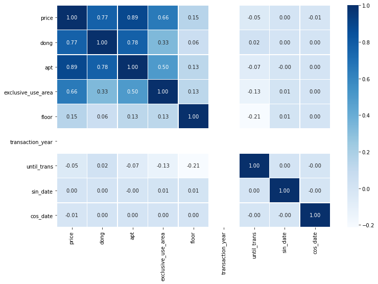

```python
encoder = CatBoostEncoder(cols=['dong','apt']).fit(val_x, val_y)
cbe_val_x = encoder.transform(val_x)
cbe_val_c = pd.concat([val_y, cbe_val_x], axis=1)

plt.figure(figsize=(12,8))
sns.heatmap(data = cbe_val_c.corr(), annot=True,
           fmt = '.2f', linewidths=.5, cmap='Blues')
```

### 2.2 릿지 튜닝

- mse를 비교해서 튜닝
- 릿지의 튜닝파라미터 알파는 0.00001, 0.0001, 0.001, 0.01, 0.1로 설정
- 알파가 클수록 강한 패널티
- 튜닝결과 시각화

```python
from sklearn.linear_model import Ridge
from sklearn.metrics import mean_squared_error
from math import sqrt
```

```python
alpha = [0.00001, 0.0001, 0.001, 0.01, 0.1]
RMSE= []

for i in alpha:
    model = Ridge(alpha=i).fit(cbe_val_x, val_y)
    pred_y = model.predict(val_cbe)
    rmse = sqrt(mean_squared_error(val_y, pred_y))
    RMSE.append(rmse)
    print('Alpha:{}, RMSE:{}'.format(i, rmse))
```

```
Alpha:1e-05, RMSE:12808.627936863946
Alpha:0.0001, RMSE:12808.627936863946
Alpha:0.001, RMSE:12808.627936863946
Alpha:0.01, RMSE:12808.627936863946
Alpha:0.1, RMSE:12808.627936863959
```

### 2.3 튜닝결과 시각화

[figure not shown]

```python
import matplotlib.pyplot as plt

ridge = Ridge(alpha=0.0001).fit(cbe_val_x,val_y)
plt.plot(ridge.coef_,'p')
plt.ylabel('coefficient')
```

### 2.5 그냥 선형 모형으로

- linear regression을 튜닝을 위한train에 적합시키고 val에 대한 rmse를 계산
- ridge랑 validation rmse를 비교해서 어떤 모형이 나은지 알아보자

```python
from sklearn.linear_model import LinearRegression
```

```python
linear = LinearRegression().fit(cbe_val_x, val_y)
pred_y = linear.predict(val_cbe)
rmse = mean_squared_error(val_y, pred_y)
sqrt(rmse)
```

```
12808.627936863946
```

## 3. LightGBM

LGBM 부스팅 모형은 강력하면서도 빠름

```python
#!pip install lightgbm
```

### 3.1 LightGBM 이해

- lgbm 장단점 장점 1.학습하는데 걸리는 시간이 적다 2.메모리 사용량이 상대적으로 적은편이다 3.카테고리형 피처들의 자동 변환과 최적 분할

단점 적은 데이터 세트에 적용을 할 경우 과적합 가능성이 크다

### 3.2 LGBM 튜닝

- 많은 튜닝파아미터(max_depth, learning_rate, lambda, min_child_samples)들 중 learning_rate만 튜닝
- [0.01, 0.05, 0.1, 0.3, 0.5, 0.7, 0.99]로 튜닝
- 일반적으로 learning rate랑 iteration의 trade off를 적절하게 고려해 학습속도를 맞어춘 후 세부적인 튜닝 진행

```python
import lightgbm as lgb
from lightgbm import LGBMModel, LGBMRegressor

rate = [0.01, 0.05, 0.1, 0.3, 0.5, 0.7, 0.99]
df = lgb.Dataset(cbe_val_x, label = val_y)
df_t = lgb.Dataset(val_cbe, label=val_y)

RMSE = []

for i in rate:
    param = {'learning_rate':i, 'force_col_wise':True}
    model = lgb.train(param, train_set = df, valid_sets=df_t)
    y_pred = model.predict(val_cbe)
    rmse = sqrt(mean_squared_error(val_y,y_pred))
    RMSE.append(rmse)
```

[output not shown]

### 3.3 튜닝결과 시각화

learning_rate의 변화에 따른 rmse의 변화를 시각화!

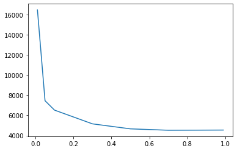

```python
plt.plot(rate, RMSE)
```

### 3.4 튜닝에 대하여 알아보자

- 방금한 튜닝은 그리드 서치(Grid Search)방법이다
- 이외의 방법으론 Random Search & Bayesian Optimization등이 있다

그리드 서치는 탐색의 대상이 되는 특정 구간 내의 후보 하이퍼 파라미터 값들을 일정한 간격을 두고 선정해, 각각에 대해 측정한 성능결과를 기록한 뒤, 가장 높은 성능을 보인 하이퍼 파라미터를 선정하는 방식으로 좀 더 균등하고 전역적인 탐색이 가능하다는 장점이 있으나 탐색하고자 하는 하이퍼파라미터의 개수가 늘어날 수록 탐색시간이 기하급수적으로 증가한다는 단점이 있다

랜덤 서치는 그리드서치와 큰 맥락은 유사하나 탐색 대상 구간 내의 후보 하이퍼파라미터 값들을 랜덤 샘플링을 통해 선정한다는 점이 다르다 즉 랜덤하게 일부의 파라미터들만 관측한 후, 그 중에서 가장 좋은 파라미터를 고르는 방식이기에 최적 하이퍼파라미터 값을 더 빨리 찾을 수 있는 장점과 그리드로 제한되지 않기에 확률적으로 더 중요한 파라미터를 더 살펴볼 수 있으나 여전히 약간의 불필요한 탐색을 반복한다는 단점이 있다

베이지안 최적화는 어는 입력값을 받는 미지의 목적함수를 상정하여 그 함숫값을 최대로 만드는 최적해를 찾는 것을 목적으로 한다. 즉 목적함수와 해당 하이퍼파라미터 쌍을 대상으로 대체 모델을 만들고 평가를 통해 순차적으로 업데이트해가며 최적의 하이퍼파라미터 조합을 탐색한다.

## 4. test set

### 4.1 test set 불러오기

- test set을 불러오고 x와 y를 분리

```python
test_y=test[['price']]
test_y.head()
test_x=test.drop(['price'],axis=1)
test_x.head()
```

|  | dong | apt | exclusive_use_area | floor | transaction_year | until_trans | sin_date | cos_date |
| --- | --- | --- | --- | --- | --- | --- | --- | --- |
| 0 | 사직동 | 광화문풍림스페이스본(9-0) | 70.80 | 1 | 5 | 10 | -1.000000e+00 | -1.836970e-16 |
| 1 | 사직동 | 광화문풍림스페이스본(9-0) | 94.51 | 8 | 5 | 10 | -2.449294e-16 | 1.000000e+00 |
| 2 | 사직동 | 광화문풍림스페이스본(9-0) | 160.85 | 11 | 5 | 10 | -2.449294e-16 | 1.000000e+00 |
| 3 | 사직동 | 광화문풍림스페이스본(9-0) | 94.51 | 6 | 5 | 10 | 1.000000e+00 | 3.061617e-16 |
| 4 | 사직동 | 광화문풍림스페이스본(9-0) | 136.40 | 3 | 5 | 10 | 1.000000e+00 | 3.061617e-16 |

### 4.2 캣부스트 인코딩

- 전체 train set에 대해 캣부스트 인코딩을 시행해주세요
- 인자에는 train_x/train_y/test_x가 들어감

```python
import category_encoders as ce

cbe_encoder = ce.cat_boost.CatBoostEncoder()
cbe_encoder.fit(train_x,train_y)
cbe_val_test = cbe_encoder.transform(test_x)
cbe_val_test.head()
```

|  | dong | apt | exclusive_use_area | floor | transaction_year | until_trans | sin_date | cos_date |
| --- | --- | --- | --- | --- | --- | --- | --- | --- |
| 0 | 91827.227742 | 89369.051084 | 70.80 | 1 | 5 | 10 | -1.000000e+00 | -1.836970e-16 |
| 1 | 91827.227742 | 89369.051084 | 94.51 | 8 | 5 | 10 | -2.449294e-16 | 1.000000e+00 |
| 2 | 91827.227742 | 89369.051084 | 160.85 | 11 | 5 | 10 | -2.449294e-16 | 1.000000e+00 |
| 3 | 91827.227742 | 89369.051084 | 94.51 | 6 | 5 | 10 | 1.000000e+00 | 3.061617e-16 |
| 4 | 91827.227742 | 89369.051084 | 136.40 | 3 | 5 | 10 | 1.000000e+00 | 3.061617e-16 |

### 4.3 최적의 파라미터 적합

```python
#linear regression
enc = CatBoostEncoder(cols=['dong','apt']).fit(train_x, train_y)
cbe_train_x = enc.transform(train_x)
lm = LinearRegression().fit(cbe_val_x, val_y)

#lgbm
df = lgb.Dataset(cbe_val_x, label=val_y)
df_t = lgb.Dataset(cbe_val_test, label=test_y)

param = {'learning_rate':0.5,'force_col_wise':True}
model = lgb.train(param, train_set=df, valid_sets=df_t)
```

```
[LightGBM] [Info] Total Bins 877
[LightGBM] [Info] Number of data points in the train set: 109698, number of used features: 7
[LightGBM] [Info] Start training from score 53693.710223
```

### 4.4 test set에 대해 평가

```python
#linear regression
pred_y = lm.predict(cbe_val_test)
rmse_linear = sqrt(mean_squared_error(test_y, pred_y))

#lgbm
y_pred = model.predict(cbe_val_test)
rmse_lgbm = sqrt(mean_squared_error(test_y, y_pred))

print(rmse_linear, rmse_lgbm)
```

```
19972.27940903686 19622.24423817203
```

lgbm의 rmse가 linear regression의 rmse보다 작아 lgbm이 좀더 성능이 좋다고 볼수 있다..?!